# MY470 - Exercise Week 8 - Programming

Pablo Barberá

The goal of this exercise is to practice writing code in R. You will have to use the content from this week’s lecture as well as the required readings and the R documentation in order to answer the questions below.

We will mark the assignment based on the compiled html file, so please check that the final version of your submission includes that file. Submissions without a compiled html file will receive a mark of 0.

### 1. Working with text

Here, we revisit some of the same issues as in [Week 2](https://github.com/lse-my470/assignment-2/blob/master/MY470_wk2_assign.ipynb).

We will use the same text:

```r
txt <- "Someone must have been telling lies about Josef K., he knew he had
done nothing wrong but, one morning, he was arrested.  Every day at
eight in the morning he was brought his breakfast by  Mrs. Grubach's
cook - Mrs. Grubach was his landlady - but today she didn't come.  That
had never happened before.  K. waited a little while, looked from his
pillow at the old woman who lived opposite and who was watching him with
an inquisitiveness quite unusual for her, and finally, both hungry and
disconcert"

# this splits the text by whitespace
toks <- unlist(strsplit(txt, "\\s"))
```

Answer the questions below by creating your own chunks of code to find the right answer:

1. What is the type of the object `toks`? (Hint: Examine it using the same tools as from the lecture notes.)

*The object `toks` is of class “character”*

```r
typeof(toks)
```

```
## [1] "character"
```

```r
class(toks)
```

```
## [1] "character"
```

2. How many elements are in `toks`? And how many *unique* elements?

*There are 93 elements, and 74 of them are unique.*

```r
length(toks)
```

```
## [1] 93
```

```r
length(unique(toks))
```

```
## [1] 74
```

3. What are the most common three words? Hint: See `?table`.

*The three most common words are was, he, and his.*

```r
# delete punctuation
toks <- gsub("[[:punct:]]", "", toks)
# convert to lower case
toks <- tolower(toks)
# deleting empty words
toks <- toks[toks!=""]

tail(sort(table(toks)))
```

```
## toks
## the who and his  he was
##   2   2   3   3   4   4
```

4. Try this using the **quanteda** package. Functions to perform the above steps are `tokens()`, `ntoken()`, `ntype()`, and `topfeatures`.

*Results are different from our code above because quanteda treats punctuation differently.*

```r
library(quanteda)
toks <- tokens(txt)
ntoken(toks)
```

```
## text1
##   102
```

```r
ntype(toks)
```

```
## text1
##    72
```

```r
topfeatures(dfm(toks))
```

```
##       .       ,      he     was     his     and       k     had     but
##       7       6       4       4       3       3       2       2       2
## morning
##       2
```

*Here’s how to obtain the same results with our code above and with quanteda.*

```r
# with base R:
# 1) convert to lowercase
new_txt <- tolower(txt)
# 2) remove line breaks
new_txt <- gsub("\\n", " ", new_txt)
# 3) removing punctuation
new_txt <- gsub("[[:punct:]]", "", new_txt)
# 4) removing double splaces
new_txt <- gsub("  ", " ", new_txt)

# and now we run the code above...
toks <- unlist(strsplit(new_txt, "\\s"))
length(toks)
```

```
## [1] 87
```

```r
length(unique(toks))
```

```
## [1] 69
```

```r
# and we get the same as with quanteda
toks <- tokens(txt, remove_punct=TRUE)
ntoken(toks)
```

```
## text1
##    87
```

```r
ntype(toks)
```

```
## text1
##    69
```

```r
topfeatures(dfm(toks))
```

```
##      he     was     his     and       k     had     but morning      at
##       4       4       3       3       2       2       2       2       2
##     the
##       2
```

### 2. Working with a dataset.

This exercise relates to the `College` data set, which comes from [An Introduction to Statistical Learning](http://www-bcf.usc.edu/~gareth/ISL/data.html) by James et al 2013. It contains a number of variables for 777 different universities and colleges in the US.

For convenience, we have placed the `.csv` file in this repository.

Use the `read.csv()` function to read the data into `R`. Call the loaded data `college`. Make sure that you have the directory set to the correct location for the data. You can load this in R directly from the website, using:

```r
college <- read.csv("http://www-bcf.usc.edu/~gareth/ISL/College.csv")
```

Or you can load it from a saved file, using (you might need to modify the path):

```r
college <- read.csv("College.csv")
```

1. Look at the data using the `View()` function. Create a code block and output the results of printing the first 6 rows of the dataset, using the `head()` function.

```r
head(college)
```

```
##                              X Private Apps Accept Enroll Top10perc
## 1 Abilene Christian University     Yes 1660   1232    721        23
## 2           Adelphi University     Yes 2186   1924    512        16
## 3               Adrian College     Yes 1428   1097    336        22
## 4          Agnes Scott College     Yes  417    349    137        60
## 5    Alaska Pacific University     Yes  193    146     55        16
## 6            Albertson College     Yes  587    479    158        38
##   Top25perc F.Undergrad P.Undergrad Outstate Room.Board Books Personal PhD
## 1        52        2885         537     7440       3300   450     2200  70
## 2        29        2683        1227    12280       6450   750     1500  29
## 3        50        1036          99    11250       3750   400     1165  53
## 4        89         510          63    12960       5450   450      875  92
## 5        44         249         869     7560       4120   800     1500  76
## 6        62         678          41    13500       3335   500      675  67
##   Terminal S.F.Ratio perc.alumni Expend Grad.Rate
## 1       78      18.1          12   7041        60
## 2       30      12.2          16  10527        56
## 3       66      12.9          30   8735        54
## 4       97       7.7          37  19016        59
## 5       72      11.9           2  10922        15
## 6       73       9.4          11   9727        55
```

2. Use the `str()` function to look at the structure of the data. Which of the variables are numeric? Which are integer? Which are factors?

```r
str(college)
```

```
## 'data.frame':    777 obs. of  19 variables:
##  $ X          : Factor w/ 777 levels "Abilene Christian University",..: 1 2 3 4 5 6 7 8 9 10 ...
##  $ Private    : Factor w/ 2 levels "No","Yes": 2 2 2 2 2 2 2 2 2 2 ...
##  $ Apps       : int  1660 2186 1428 417 193 587 353 1899 1038 582 ...
##  $ Accept     : int  1232 1924 1097 349 146 479 340 1720 839 498 ...
##  $ Enroll     : int  721 512 336 137 55 158 103 489 227 172 ...
##  $ Top10perc  : int  23 16 22 60 16 38 17 37 30 21 ...
##  $ Top25perc  : int  52 29 50 89 44 62 45 68 63 44 ...
##  $ F.Undergrad: int  2885 2683 1036 510 249 678 416 1594 973 799 ...
##  $ P.Undergrad: int  537 1227 99 63 869 41 230 32 306 78 ...
##  $ Outstate   : int  7440 12280 11250 12960 7560 13500 13290 13868 15595 10468 ...
##  $ Room.Board : int  3300 6450 3750 5450 4120 3335 5720 4826 4400 3380 ...
##  $ Books      : int  450 750 400 450 800 500 500 450 300 660 ...
##  $ Personal   : int  2200 1500 1165 875 1500 675 1500 850 500 1800 ...
##  $ PhD        : int  70 29 53 92 76 67 90 89 79 40 ...
##  $ Terminal   : int  78 30 66 97 72 73 93 100 84 41 ...
##  $ S.F.Ratio  : num  18.1 12.2 12.9 7.7 11.9 9.4 11.5 13.7 11.3 11.5 ...
##  $ perc.alumni: int  12 16 30 37 2 11 26 37 23 15 ...
##  $ Expend     : int  7041 10527 8735 19016 10922 9727 8861 11487 11644 8991 ...
##  $ Grad.Rate  : int  60 56 54 59 15 55 63 73 80 52 ...
```

3. Use the `summary()` function to produce a numerical summary of the variables in the data set.

```r
summary(college)
```

```
##                             X       Private        Apps
##  Abilene Christian University:  1   No :212   Min.   :   81
##  Adelphi University          :  1   Yes:565   1st Qu.:  776
##  Adrian College              :  1             Median : 1558
##  Agnes Scott College         :  1             Mean   : 3002
##  Alaska Pacific University   :  1             3rd Qu.: 3624
##  Albertson College           :  1             Max.   :48094
##  (Other)                     :771
##      Accept          Enroll       Top10perc       Top25perc
##  Min.   :   72   Min.   :  35   Min.   : 1.00   Min.   :  9.0
##  1st Qu.:  604   1st Qu.: 242   1st Qu.:15.00   1st Qu.: 41.0
##  Median : 1110   Median : 434   Median :23.00   Median : 54.0
##  Mean   : 2019   Mean   : 780   Mean   :27.56   Mean   : 55.8
##  3rd Qu.: 2424   3rd Qu.: 902   3rd Qu.:35.00   3rd Qu.: 69.0
##  Max.   :26330   Max.   :6392   Max.   :96.00   Max.   :100.0
##
##   F.Undergrad     P.Undergrad         Outstate       Room.Board
##  Min.   :  139   Min.   :    1.0   Min.   : 2340   Min.   :1780
##  1st Qu.:  992   1st Qu.:   95.0   1st Qu.: 7320   1st Qu.:3597
##  Median : 1707   Median :  353.0   Median : 9990   Median :4200
##  Mean   : 3700   Mean   :  855.3   Mean   :10441   Mean   :4358
##  3rd Qu.: 4005   3rd Qu.:  967.0   3rd Qu.:12925   3rd Qu.:5050
##  Max.   :31643   Max.   :21836.0   Max.   :21700   Max.   :8124
##
##      Books           Personal         PhD            Terminal
##  Min.   :  96.0   Min.   : 250   Min.   :  8.00   Min.   : 24.0
##  1st Qu.: 470.0   1st Qu.: 850   1st Qu.: 62.00   1st Qu.: 71.0
##  Median : 500.0   Median :1200   Median : 75.00   Median : 82.0
##  Mean   : 549.4   Mean   :1341   Mean   : 72.66   Mean   : 79.7
##  3rd Qu.: 600.0   3rd Qu.:1700   3rd Qu.: 85.00   3rd Qu.: 92.0
##  Max.   :2340.0   Max.   :6800   Max.   :103.00   Max.   :100.0
##
##    S.F.Ratio      perc.alumni        Expend        Grad.Rate
##  Min.   : 2.50   Min.   : 0.00   Min.   : 3186   Min.   : 10.00
##  1st Qu.:11.50   1st Qu.:13.00   1st Qu.: 6751   1st Qu.: 53.00
##  Median :13.60   Median :21.00   Median : 8377   Median : 65.00
##  Mean   :14.09   Mean   :22.74   Mean   : 9660   Mean   : 65.46
##  3rd Qu.:16.50   3rd Qu.:31.00   3rd Qu.:10830   3rd Qu.: 78.00
##  Max.   :39.80   Max.   :64.00   Max.   :56233   Max.   :118.00
##
```

4. What is the mean and standard deviation of the `Enroll` and `Top10Perc` variables? You should use the functions `mean()` and `sd()` for the answer.

```r
mean(college$Enroll)
```

```
## [1] 779.973
```

```r
sd(college$Enroll)
```

```
## [1] 929.1762
```

```r
mean(college$Top10perc)
```

```
## [1] 27.55856
```

```r
sd(college$Top10perc)
```

```
## [1] 17.64036
```

5. Now remove the 10th through 85th observations. This will involve slicing the data, similar to in Python, but for the row element. What is the mean and standard deviation of the `Enroll` and `Top10Perc` variables in the subset of the data that remains?

```r
mean(college$Enroll[-(10:85)])
```

```
## [1] 787.913
```

```r
sd(college$Enroll[-(10:85)])
```

```
## [1] 931.2228
```

```r
mean(college$Top10perc[-(10:85)])
```

```
## [1] 27.45221
```

```r
sd(college$Top10perc[-(10:85)])
```

```
## [1] 17.64522
```

```r
# or:
college_subset <- college[-(10:85),]
mean(college_subset$Enroll)
```

```
## [1] 787.913
```

```r
sd(college_subset$Enroll)
```

```
## [1] 931.2228
```

```r
mean(college_subset$Top10perc)
```

```
## [1] 27.45221
```

```r
sd(college_subset$Top10perc)
```

```
## [1] 17.64522
```

6. What is the range of the `Books` variable? Hint: Use `range()`.

```r
range(college$Books)
```

```
## [1]   96 2340
```

7. Produce a scatterplot matrix of the first five numeric variables of the dataset.

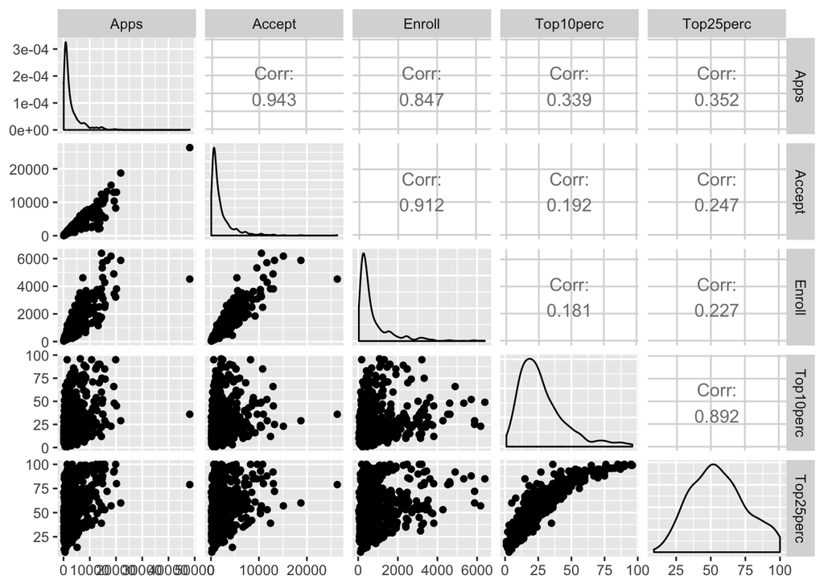

```r
library(ggplot2)
library(GGally)
ggpairs(college[,c("Apps", "Accept", "Enroll", "Top10perc", "Top25perc")])
```